# Intro

My notes

1. In the installation steps, show how to create a .py or a .ipynb file using JupyterLab, and mention the difference between html and .ipynb (the .ipynb files should be available somewhere)
2. Useful tips to use Notebooks (make a paragraph almost at the beginning)
- [7 Essential Tols for Writng Notebooks](https://towardsdatascience.com/7-essential-tips-for-writing-with-jupyter-notebook-60972a1a8901)
- [IBM Cheat Sheet](https://www.ibm.com/docs/en/watson-studio-local/1.2.3?topic=notebooks-markdown-jupyter-cheatsheet)
1. I have exercises from the class at IHEID (Fibonacci etc)

# About Python

## Contents

- About Python
  - Intro to Programming Language
  - Intro to Python
  - Local Installation

## Intro to Programming Language

- A programming language is a structured subset of natural language (words) and special characters (e.g. `,` or `{`) that allow humans to describe operations they would like their computer to perform on their behalf.
- The programming language translates these words and symbols into instructions the computer can execute.

$\color{red}{\text{Maybe here add something on interpreter, kernel, RAM, binary code, etc}}$

## Intro to Python

- [Python](https://www.python.org) is a general-purpose programming language conceived in 1989 by Dutch programmer [Guido van Rossum](https://en.wikipedia.org/wiki/Guido_van_Rossum).
- Python is free and open source, with development coordinated through the [Python Software Foundation](https://www.python.org/psf/).
- Python has experienced rapid adoption in the last decade and is now one of the most popular programming languages ([third most popular](https://www.zdnet.com/article/programming-language-of-the-year-python-is-standout-in-latest-rankings/) and the most popular scripting language)

### Common Use

- Python is very beginner-friendly
- Python can be used for data analysis, but it can also used for websites, database management, web scraping, financial modeling, data visualization, etc. In particular, it is the world’s best language for [gluing](https://en.wikipedia.org/wiki/Glue_code) those different pieces together.
- Python is also used extensively by Internet services and high tech companies (e.g. [Google](https://www.google.com/))
- Python is also used to [replace Excel](https://news.efinancialcareers.com/us-en/3002556/python-replaced-excel-banking) in the fields of finance and banking.

### Comparison to Other Languages

Other languages can be more perfomant for other types of tasks. For example:

- R has an impressive ecosystem of statistical packages, and is defensible as a choice for pure data science. It could be a useful second language to learn for projects that are entirely statistical.
- Matlab has much more natural notation for writing linear algebra heavy code. However, it is: (a) expensive; (b) poor at dealing with data analysis; (c) grossly inferior to Python as a language; and (d) being left behind as Python and Julia ecosystems expand to more packages.
- Julia is in part a far better version of Matlab, which can be as fast as Fortran or C. However, it has a young and immature environment and is currently more appropriate for academics and scientific computing specialists.

For runtime performance, Python, R, and Matlab can be slow for certain types of tasks. Most of the data analytics packages in Python (and R) rely on high-performance code written in other languages in the background (i.e. C++). In addition, there are Python/R packages which allow you to write and read your own C program.

### Popularity

This graph by QuantEcon (produced using Stack Overflow Trends) shows one measure of the relative popularity of Python:

[figure not shown]

The graph shows that

1. Python is widely used with respect to Matlab
2. The doption of Python has accelerated significantly since 2012, possibly because of uptake in the scientific domain and thanks to the release of data-abnalysis libraries like [pandas](http://pandas.pydata.org/)

Overall, it’s clear that

- Python is [one of the most popular programming languages worldwide](https://spectrum.ieee.org/computing/software/the-top-programming-languages-2019).
- Python is a major tool for scientific computing, accounting for a rapidly rising share of scientific work around the globe.

### Features

1. Python is a [high-level language](https://en.wikipedia.org/wiki/High-level_programming_language) suitable for rapid development.
2. It has a relatively small core language supported by many libraries.
3. Python is open source and is thus managed on publicly accessible sites (e.g. GitHub) by a large community.
4. Other features of Python:
   - multiple programming styles are supported (procedural, object-oriented, functional, etc.)
   - it is interpreted rather than compiled. $\color{red}{\text{note: this second point is good to keep but we need to know what it means exactly}}$

### Syntax and Design

1. Elegant syntax: elegant code might sound superfluous but in fact it’s highly beneficial because it makes the syntax easy to read and easy to remember.
2. Elegant design: features like iterators, generators, decorators and list comprehensions make Python highly expressive, allowing you to get more done with less code.

[Namespaces](https://en.wikipedia.org/wiki/Namespace) improve productivity by cutting down on bugs and syntax errors.

### Scientific Programming

- Python has become one of the core languages of scientific computing.
- It’s either the dominant player or a major player in
  - [machine learning and data science](http://scikit-learn.org/stable/)
  - [astronomy](http://www.astropy.org/)
  - [artificial intelligence](https://wiki.python.org/moin/PythonForArtificialIntelligence)
  - [chemistry](http://chemlab.github.io/chemlab/)
  - [computational biology](http://biopython.org/wiki/Main_Page)
  - [meteorology](https://pypi.org/project/meteorology/)
- Its popularity in economics is also beginning to rise.

### Numerical Programming

- Fundamental matrix and array processing capabilities are provided by the excellent [NumPy](http://www.numpy.org/) library.
- NumPy provides the basic array data type plus some simple processing operations.

For example, let’s build some arrays

```python
import numpy as np                     # Load the library

a = np.linspace(-np.pi, np.pi, 100)    # Create even grid from -π to π
b = np.cos(a)                          # Apply cosine to each element of a
c = np.sin(a)                          # Apply sin to each element of a
```

```python
b @ c
```

```
9.020562075079397e-16
```

- The number you see here might vary slightly but it’s essentially zero.
- The [SciPy](http://www.scipy.org) library is built on top of NumPy and provides additional functionality.

For example, let’s calculate $ \int_{-2}^2 \phi(z) dz $ where $ \phi $ is the standard normal density.

```python
from scipy.stats import norm
from scipy.integrate import quad

ϕ = norm()
value, error = quad(ϕ.pdf, -2, 2)  # Integrate using Gaussian quadrature
value
```

```
0.9544997361036417
```

SciPy includes many of the standard routines used in

- [linear algebra](http://docs.scipy.org/doc/scipy/reference/linalg.html)
- [integration](http://docs.scipy.org/doc/scipy/reference/integrate.html)
- [interpolation](http://docs.scipy.org/doc/scipy/reference/interpolate.html)
- [optimization](http://docs.scipy.org/doc/scipy/reference/optimize.html)
- [distributions and random number generation](http://docs.scipy.org/doc/scipy/reference/stats.html)
- [signal processing](http://docs.scipy.org/doc/scipy/reference/signal.html)

See them all [here](http://docs.scipy.org/doc/scipy/reference/index.html).

### Graphs

The most popular and comprehensive Python library for creating figures and graphs is [Matplotlib](http://matplotlib.org/), with functionality including

- plots, histograms, contour images, 3D graphs, bar charts etc.
- output in many formats (PDF, PNG, EPS, etc.)
- LaTeX integration

Example 2D plot with embedded LaTeX annotations

[figure not shown]

Example contour plot

[figure not shown]

Example 3D plot

[figure not shown]

More examples can be found in the [Matplotlib thumbnail gallery](http://matplotlib.org/gallery.html).

Other graphics libraries include

- [Plotly](https://plot.ly/python/)
- [Bokeh](http://bokeh.pydata.org/en/latest/)
- [VPython](http://www.vpython.org/) — 3D graphics and animations

### Symbolic Algebra

- You can manipulate symbolic expressions, as in Mathematica or Maple.
- The [SymPy](http://www.sympy.org/) library provides this functionality from within the Python shell. $\color{red}{\text{note: check what it means exactly "from within the Python shell"}}$

```python
from sympy import Symbol

x, y = Symbol('x'), Symbol('y')  # Treat 'x' and 'y' as algebraic symbols
x + x + x + y
```

$\displaystyle 3 x + y$

We can manipulate expressions

```python
expression = (x + y)**2
expression.expand()
```

$\displaystyle x^{2} + 2 x y + y^{2}$

solve polynomials

```python
from sympy import solve

solve(x**2 + x + 2)
```

```
[-1/2 - sqrt(7)*I/2, -1/2 + sqrt(7)*I/2]
```

and calculate limits, derivatives and integrals

```python
from sympy import limit, sin, diff

limit(1 / x, x, 0)
```

$\displaystyle \infty$

```python
limit(sin(x) / x, x, 0)
```

$\displaystyle 1$

```python
diff(sin(x), x)
```

$\displaystyle \cos{\left(x \right)}$

The beauty of importing this functionality into Python is that we are working within a fully fledged programming language.

We can easily create tables of derivatives, generate LaTeX output, add that output to figures and so on.

### Statistics

There are multiple libraries in Python for data manipulation and statistics.

#### Pandas

- One of the most popular libraries for working with data is [pandas](http://pandas.pydata.org/).
- Pandas is fast, efficient, flexible and well designed.
- Here’s a simple example, using some dummy data generated with Numpy’s excellent `random` functionality.

```python
import pandas as pd # import the pandas libraries
np.random.seed(1234) # set random seed

data = np.random.randn(5, 2)  # 5x2 matrix of N(0, 1) random draws (always write the dimension of matrices)
dates = pd.date_range('28/12/2010', periods=5) # create a vector with 5 periods

df = pd.DataFrame(data, columns=('price', 'weight'), index=dates) # create a dataframe with price and weight,
# index it with dates, and save it as "df"
print(df) # print df
```

```
               price    weight
2010-12-28  0.471435 -1.190976
2010-12-29  1.432707 -0.312652
2010-12-30 -0.720589  0.887163
2010-12-31  0.859588 -0.636524
2011-01-01  0.015696 -2.242685
```

```python
df.mean() # get mean of variables
```

```
price     0.411768
weight   -0.699135
dtype: float64
```

#### Other Useful Statistics Libraries

- [statsmodels](http://statsmodels.sourceforge.net/) — various statistical routines
- [scikit-learn](http://scikit-learn.org/) — machine learning in Python (sponsored by Google, among others)
- [pyMC](http://pymc-devs.github.io/pymc/) — for Bayesian data analysis
- [pystan](https://pystan.readthedocs.org/en/latest/) Bayesian analysis based on [stan](http://mc-stan.org/)

### Networks and Graphs

Python has many libraries for studying graphs.

One well-known example is [NetworkX](http://networkx.github.io/). Its features include, among many other things:

- standard graph algorithms for analyzing networks
- plotting routines

Here’s some example code that generates and plots a random graph, with node color determined by shortest path length from a central node.

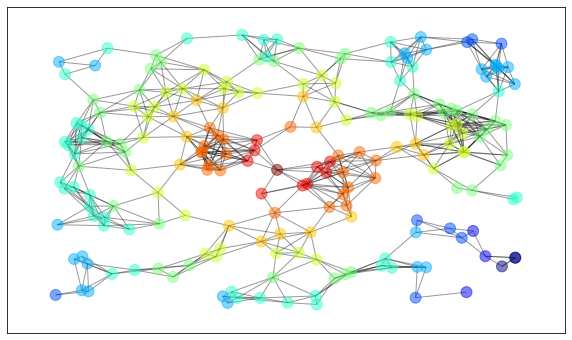

```python
%matplotlib inline
import networkx as nx
import matplotlib.pyplot as plt
plt.rcParams['figure.figsize'] = (10,6)
np.random.seed(1234)

# Generate a random graph
p = dict((i, (np.random.uniform(0, 1), np.random.uniform(0, 1)))
         for i in range(200))
g = nx.random_geometric_graph(200, 0.12, pos=p)
pos = nx.get_node_attributes(g, 'pos')

# Find node nearest the center point (0.5, 0.5)
dists = [(x - 0.5)**2 + (y - 0.5)**2 for x, y in list(pos.values())]
ncenter = np.argmin(dists)

# Plot graph, coloring by path length from central node
p = nx.single_source_shortest_path_length(g, ncenter)
plt.figure()
nx.draw_networkx_edges(g, pos, alpha=0.4)
nx.draw_networkx_nodes(g,
                       pos,
                       nodelist=list(p.keys()),
                       node_size=120, alpha=0.5,
                       node_color=list(p.values()),
                       cmap=plt.cm.jet_r)
plt.show()
```

### Cloud Computing

Running your Python code on massive servers in the cloud is becoming easier and easier.

A nice example is [Anaconda Enterprise](https://www.anaconda.com/enterprise/).

See also

- [Amazon Elastic Compute Cloud](http://aws.amazon.com/ec2/)
- The [Google App Engine](https://cloud.google.com/appengine/) (Python, Java, PHP or Go)
- [Pythonanywhere](https://www.pythonanywhere.com/)
- [Sagemath Cloud](https://cloud.sagemath.com/)

### Parallel Processing

Examples of parallel processing:

- [Parallel computing through IPython clusters](http://ipython.org/ipython-doc/stable/parallel/parallel_demos.html).
- The [Starcluster](http://star.mit.edu/cluster/) interface to Amazon’s EC2.
- GPU programming through PyCuda, [PyOpenCL](https://mathema.tician.de/software/pyopencl/), [Theano](https://en.wikipedia.org/wiki/Theano_%28software%29) or similar.

### Other Developments

Examples of other developments:

- [Jupyter](http://jupyter.org/) — Python in your browser with interactive code cells, embedded images and other useful features (this is what we are using).
- [Numba](http://numba.pydata.org/) — Make Python run at the same speed as native machine code!
- [Blaze](http://blaze.pydata.org/) — a generalization of NumPy.
- [PyTables](http://www.pytables.org) — manage large data sets.
- [CVXPY](https://github.com/cvxgrp/cvxpy) — convex optimization in Python.

### Learn More

- Browse some Python projects on [GitHub](https://github.com/trending?l=python).
- Read more about [Python’s history and rise in popularity](https://www.welcometothejungle.com/en/articles/btc-python-popular) .
- Have a look at [some of the Jupyter notebooks](http://nbviewer.jupyter.org/) people have shared on various scientific topics.
- Visit the [Python Package Index](https://pypi.org/).
- View some of the questions people are asking about Python on [Stackoverflow](http://stackoverflow.com/questions/tagged/python).
- Keep up to date on what’s happening in the Python community with the [Python subreddit](https://www.reddit.com:443/r/Python/).